# Multi-trait Analysis of Gene-by-Environment Interactions Using Summary Statistics of Genetic Marginal Effects

# Multi-trait Analysis of Gene-by-Environment Interactions Using Summary Statistics of Genetic Marginal Effects

Lan Luo

## Contents

- Overview
- System Requirements
- Installation Guide
- Demo
- URLs and References

## Overview

Studying genotype-by-environment interaction (GEI) is fundamental in understanding complex trait variations. Identifying genetic variants with GEI effects is challenging because the GEI analysis generally has low power. MAGENTA (Multi-trait Analysis of Gene-ENvironmenT-wide Association) is a powerful, robust, and computationally efficient method to test the interaction between a gene and environmental groups on multiple traits in large-scale datasets, such as the UK Biobank. More details about MAGENTA can be found in Luo et al. (2022).

Specifically, `MAGENTA` package has functions to

- compute the summary statistics with different types of data input adjusting for the potential overlapping samples under different assumption of genetic marginal effects; and
- perform summary-statistics-based multi-trait analysis of gene-environment interaction (GEI) tests or genetic main effect and GEI joint effect for both common and rare variants.

Studying genotype-by-environment interaction (GEI) is fundamental in understanding complex trait variations. Identifying genetic variants with GEI effects is challenging because the GEI analysis generally has low power. MAGENTA (Multi-trait Analysis of Gene-ENvironmenT-wide Association) is a powerful, robust, and computationally efficient method to test the interaction between a gene and environmental groups on multiple traits in large-scale datasets, such as the UK Biobank. More details about MAGENTA can be found in Luo et al. (2022).

Specifically, `MAGENTA` package has functions to

- compute the summary statistics with different types of data input adjusting for the potential overlapping samples under different assumption of genetic marginal effects; and
- perform summary-statistics-based multi-trait analysis of gene-environment interaction (GEI) tests or genetic main effect and GEI joint effect for both common and rare variants.

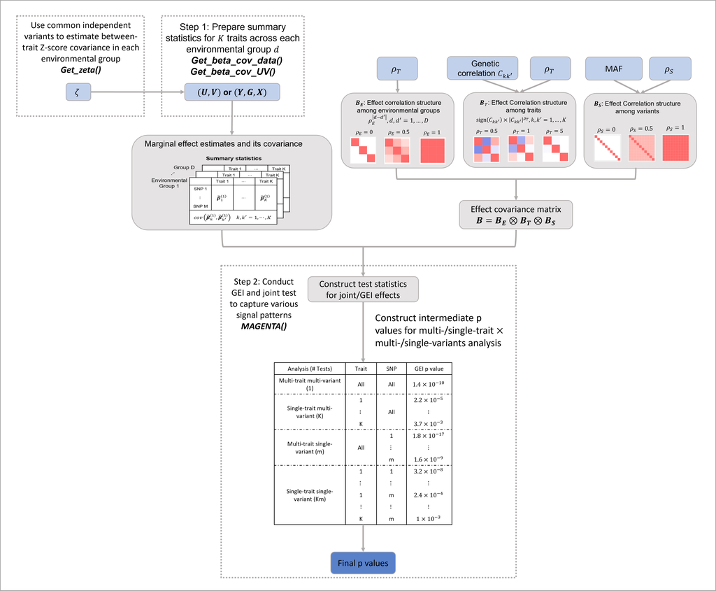

## System Requirements

The package development version is tested on the following systems:

Mac OSX: Mojave version 10.14.6 (R version 3.6.0)

Windows 10 (R version 3.6.1)

The CRAN package should be compatible with Windows and Mac operating systems.

## Installing Guide

`MAGENTA` package requires R with version 3.6.1 or higher, which can be downloaded and installed from [Github](https://github.com/lan/MAGENTA).

```
install.packages("MAGENTA.tar.gz", repos = NULL, type = "source")
```

### Package dependencies

`MAGENTA` package depends on several R packages, which will be downloaded before installing `MAGENTA`. `MAGENTA` also uses non-exported R code from R packages `ACAT` and `SKAT` as they appear on `CRAN` or `github` on January 23, 2020 and October 28, 2021, respectively. The versions of other software are, specifically:

The package development version is tested on the following systems:

Mac OSX: Mojave version 10.14.6 (R version 3.6.0)

Windows 10 (R version 3.6.1)

The CRAN package should be compatible with Windows and Mac operating systems.

## Installing Guide

`MAGENTA` package requires R with version 3.6.1 or higher, which can be downloaded and installed from [CRAN](https://cran.r-project.org/).

```
install.packages("MAGENTA")
```

### Package dependencies

`MAGENTA` package depends on several R packages, which will be downloaded before installing `MAGENTA`. `MAGENTA` also uses non-exported R code from R packages `ACAT` and `SKAT`. The `MAGENTA` package functions with all packages in their versions as they appear on `CRAN` or `github` on January 23, 2020 and October 28, 2021, respectively. The versions of software are, specifically:

```
MASS (>= 7.3-51.4),
Matrix (>= 1.2-17),
caret (>= 6.0-84),
stats,
utils,
gtools (>= 3.8.1),
SPAtest (>= 3.0.0),
survival (>= 3.2-3),
SKAT (>= 1.3.2.1),
expm (>= 0.999-4),
CompQuadForm (>= 1.4.3),
caret (>=6.0-84)
```

## Demo

### Step 1: Prepare Summary Statistics across environmental groups

Suppose we are interested in testing the GEI effect on $K$ traits. Under each environmental group, we estimate the genetic marginal effects of $M$ variants on the $K$ traits and the covariances of these effect estimates. Let $\mathbf{\beta}^{(d)}_k$ denote the effects of the $M$ variants on trait $k$ in environmental group $d$ and $\widehat{\mathbf{\beta}}^{(d)}_k$ denote the corresponding effect estimates. We let $\text{cov}(\widehat{\mathbf{\beta}}_k^{(d)}, \widehat{\mathbf{\beta}}_{k'}^{(d)})$ denote the covariance of $\widehat{\mathbf{\beta}}_k^{(d)}$ and $\widehat{\mathbf{\beta}}_{k'}^{(d)}$. For the same trait $k=k'$, the $\text{cov}(\widehat{\mathbf{\beta}}_k^{(d)}, \widehat{\mathbf{\beta}}_{k'}^{(d)})$ is the variance-covariance of $\widehat{\mathbf{\beta}}^{(d)}_k$. For different traits $k\neq k'$, $\text{cov}(\widehat{\mathbf{\beta}}_k^{(d)}, \widehat{\mathbf{\beta}}_{k'}^{(d)})$ quantifies the covariance between effect estimates on the two traits when they are measured on the overlapping set of subjects and $\text{cov}(\widehat{\mathbf{\beta}}_k^{(d)}, \widehat{\mathbf{\beta}}_{k'}^{(d)})=0$ if there are no overlapping subjects. For the simplicity of notation, we drop the environmental group index $(d)$ in the remaining part of this section

We first obtain the variant-level score statistics $\mathbf{U}_k$ for testing the genetic effect $\mathbf{\beta}_k = 0$ and its variance-covariance estimate $\mathbf{V}_k$. The calculation of the score statistics is computationally efficient as it fits a genotype-independent regression model (i.e., $\mathbf{\beta}_k = 0$) only once in the genome-wide analysis. We estimate the genetic effect as $\mathbf{\hat{\beta}}_k = \mathbf{V}_k^{-1}\mathbf{U}_k$. This estimate is numerically stable and accurate and has been commonly employed in the genetic association analysis of sequencing studies and shared in public domains

MAGENTA introduces below two approaches of estimating $\text{cov}(\widehat{\mathbf{\beta}}_k, \widehat{\mathbf{\beta}}_{k'})$. One approach needs individual-level data of all traits but can accurately estimate the correlation induced by the overlapping subjects across trait. The other approach utilizes only the trait-specific summary statistics $\mathbf{U}_k$ and $\mathbf{V}_k$ and is accurate when there are no genetic main effects, which is true under the null hypothesis of main test or joint test, but not necessarily the case under the null hypothesis of GEI test. This apparoch can still provide a reasonable approximation when the main effects are weak but may be inaccurate when the genetic main effects are unusually strong

#### 1. Input data is individual-level data

Assume the users provide the individual-level data $\mathbf{Y}$ for traits, $\mathbf{X}$ for covariates, $\mathbf{G}$ for genotype, respectively. Let $\widehat{\mathbf{\theta}}_k = (\widehat{\mathbf{\alpha}}^{\rm T}_k, \widehat{\mathbf{\beta}}^{\rm T}_k)^{\rm T}$ and $\mathbf{Z}_{ik} = (\mathbf{X}^{\rm T}_{ik}, \mathbf{G}^{\rm T}_{ik})^{\rm T}$ with $\widehat{\mathbf{\alpha}}^{\rm T}_k, \widehat{\mathbf{\beta}}^{\rm T}_k$ denoting the estimated regression coefficients for covariates and genotype. Without loss of generality, we organize the data such that the first $n_{kk'}$ subjects are those with measurements on both traits $k$ and $k'$. Then $\text{cov}(\widehat{\mathbf{\theta}}_{k}, \widehat{\mathbf{\theta}}_{k'})$ can be estimated as
$$\text{cov}(\widehat{\mathbf{\theta}}_{k},
\widehat{\mathbf{\theta}}_{k'}) = \left(\sum_{i = 1}^{n_k}
\widehat{b}^{''}_{ik}\mathbf{Z}_{ik}\mathbf{Z}^{\rm
T}_{ik}\right)^{-1}
\left(\sum_{i = 1}^{n_{kk'}} \mathbf{Z}_{ik} \widehat{v}^{1/2}_{ik}
\widehat{\omega}_{kk'} \widehat{v}^{1/2}_{ik'} \mathbf{Z}^{\rm
T}_{ik'}\right)
\left(\sum_{i = 1}^{n_{k'}}
\widehat{b}^{''}_{ik'}\mathbf{Z}_{ik'}\mathbf{Z}^{\rm
T}_{ik'}\right)^{-1},$$

where $\widehat{b}^{''}_{ik}=1$ and $\widehat{v}_{ik} = \widehat{\sigma}^2_k$ for the linear regression model with residual variance estimate $\widehat{\sigma}^2_k$, and $\widehat{b}^{''}_{ik}=\widehat{v}_{ik}=e^{\widehat{\mathbf{\alpha}}^{\rm T}_k\mathbf{X}_{ik}}/(1+e^{\widehat{\mathbf{\alpha}}^{\rm T}_k\mathbf{X}_{ik}})^2$ for the logistic regression model, and $\widehat{\omega}_{kk'}$ is the empirical correlation of the Pearson residuals of the two traits using their overlapping samples. The $\widehat{b}^{''}_{ik}$, $\widehat{b}^{''}_{ik'}$, $\widehat{v}_{ik}$, $\widehat{v}_{ik'}$ and $\widehat{\omega}_{kk'}$ need to compute only once over all the genes in the genome-wide analysis. We then obtain the $\text{cov}(\widehat{\mathbf{\beta}}_{k}, \widehat{\mathbf{\beta}}_{k'})$ as the submatrix of $\text{cov}(\widehat{\mathbf{\theta}}_{k}, \widehat{\mathbf{\theta}}_{k'})$ corresponding to $\widehat{\mathbf{\beta}}_k$ on the rows and $\widehat{\mathbf{\beta}}_{k'}$ on the columns.

```r
data("rawdata")
attach(rawdata)
head(dat)
```

[output not shown]

Suppose we are interested in testing the GEI effect on $K$ traits. Under each environmental group, we estimate the genetic marginal effects of $M$ variants on the $K$ traits and the covariances of these effect estimates. Let $\mathbf{\beta}^{(d)}_k$ denote the effects of the $M$ variants on trait $k$ in environmental group $d$ and $\widehat{\mathbf{\beta}}^{(d)}_k$ denote the corresponding effect estimates. We let $\text{cov}(\widehat{\mathbf{\beta}}_k^{(d)}, \widehat{\mathbf{\beta}}_{k'}^{(d)})$ denote the covariance of $\widehat{\mathbf{\beta}}_k^{(d)}$ and $\widehat{\mathbf{\beta}}_{k'}^{(d)}$. For the same trait $k=k'$, the $\text{cov}(\widehat{\mathbf{\beta}}_k^{(d)}, \widehat{\mathbf{\beta}}_{k'}^{(d)})$ is the variance-covariance of $\widehat{\mathbf{\beta}}^{(d)}_k$. For different traits $k\neq k'$, $\text{cov}(\widehat{\mathbf{\beta}}_k^{(d)}, \widehat{\mathbf{\beta}}_{k'}^{(d)})$ quantifies the covariance between effect estimates on the two traits when they are measured on the overlapping set of subjects and $\text{cov}(\widehat{\mathbf{\beta}}_k^{(d)}, \widehat{\mathbf{\beta}}_{k'}^{(d)})=0$ if there are no overlapping subjects. For the simplicity of notation, we drop the environmental group index $(d)$ in the remaining part of this section

The variant-level score statistics $\mathbf{U}_k$ for testing the genetic effect $\mathbf{\beta}_k = 0$ and its variance-covariance estimate $\mathbf{V}_k$ are routinely used to construct the marginal effect estimates $\widehat{\mathbf{\beta}}_k = \mathbf{V}^{-1}_k\mathbf{U}_k$.

MAGENTA introduces below two approaches of estimating $\text{cov}(\widehat{\mathbf{\beta}}_k, \widehat{\mathbf{\beta}}_{k'})$. One approach needs individual-level data of all traits but can accurately estimate the correlation induced by the overlapping subjects across trait. The other approach utilizes only the trait-specific summary statistics $\mathbf{U}_k$ and $\mathbf{V}_k$ and is accurate when there are no genetic main effects, which is true under the null hypothesis of main test or joint test, but not necessarily the case under the null hypothesis of GEI test. This apparoch can still provide a reasonable approximation when the main effects are weak but may be inaccurate when the genetic main effects are unusually strong

#### 1. Input data is individual-level data

Assume the users provide the individual-level data $\mathbf{Y}$ for traits, $\mathbf{X}$ for covariates, $\mathbf{G}$ for genotype, respectively. Let $\widehat{\mathbf{\theta}}_k = (\widehat{\mathbf{\alpha}}^{\rm T}_k, \widehat{\mathbf{\beta}}^{\rm T}_k)^{\rm T}$ and $\mathbf{Z}_{ik} = (\mathbf{X}^{\rm T}_{ik}, \mathbf{G}^{\rm T}_{ik})^{\rm T}$ with $\widehat{\mathbf{\alpha}}^{\rm T}_k, \widehat{\mathbf{\beta}}^{\rm T}_k$ denoting the estimated regression coefficients for covariates and genotype. Without loss of generality, we organize the data such that the first $n_{kk'}$ subjects are those with measurements on both traits $k$ and $k'$. Then $\text{cov}(\widehat{\mathbf{\theta}}_{k}, \widehat{\mathbf{\theta}}_{k'})$ can be estimated as
$$\text{cov}(\widehat{\mathbf{\theta}}_{k}, \widehat{\mathbf{\theta}}_{k'}) = \left(\sum_{i = 1}^{n_k} \widehat{b}^{''}_{ik}\mathbf{Z}_{ik}\mathbf{Z}^{\rm T}_{ik}\right)^{-1}
\left(\sum_{i = 1}^{n_{kk'}} \mathbf{Z}_{ik} \widehat{v}^{1/2}_{ik} \widehat{\omega}_{kk'} \widehat{v}^{1/2}_{ik'} \mathbf{Z}^{\rm T}_{ik'}\right)
\left(\sum_{i = 1}^{n_{k'}} \widehat{b}^{''}_{ik'}\mathbf{Z}_{ik'}\mathbf{Z}^{\rm T}_{ik'}\right)^{-1},$$

where $\widehat{b}^{''}_{ik}=1$ and $\widehat{v}_{ik} = \widehat{\sigma}^2_k$ for the linear regression model with residual variance estimate $\widehat{\sigma}^2_k$, and $\widehat{b}^{''}_{ik}=\widehat{v}_{ik}=e^{\widehat{\mathbf{\alpha}}^{\rm T}_k\mathbf{X}_{ik}}/(1+e^{\widehat{\mathbf{\alpha}}^{\rm T}_k\mathbf{X}_{ik}})^2$ for the logistic regression model, and $\widehat{\omega}_{kk'}$ is the empirical correlation of the Pearson residuals of the two traits using their overlapping samples. The $\widehat{b}^{''}_{ik}$, $\widehat{b}^{''}_{ik'}$, $\widehat{v}_{ik}$, $\widehat{v}_{ik'}$ and $\widehat{\omega}_{kk'}$ need to compute only once over all the genes in the genome-wide analysis. We then obtain the $\text{cov}(\widehat{\mathbf{\beta}}_{k}, \widehat{\mathbf{\beta}}_{k'})$ as the submatrix of $\text{cov}(\widehat{\mathbf{\theta}}_{k}, \widehat{\mathbf{\theta}}_{k'})$ corresponding to $\widehat{\mathbf{\beta}}_k$ on the rows and $\widehat{\mathbf{\beta}}_{k'}$ on the columns.

```r
data("rawdata")
attach(rawdata)
head(dat)
```

```
##          ID      Trait1     Trait2     Trait3 cov1        cov2 treatment
## Ind_1 Ind_1  0.45447705  1.1491540  1.1863628    0 -0.60189285         0
## Ind_2 Ind_2 -0.25349902  1.8013214  1.6221276    1 -0.99369859         1
## Ind_3 Ind_3 -0.35372148 -0.5949716 -1.3153919    0  1.02678506         0
## Ind_4 Ind_4 -0.03748654 -1.6452761  0.4100598    1  0.75106130         1
## Ind_5 Ind_5 -0.17780654 -2.1517696 -1.2680816    1 -1.50916654         0
## Ind_6 Ind_6 -0.07654035  1.0356779 -0.8735768    0 -0.09514745         1
```

```r
colnames(geno.dat)
```

[output not shown]

```r
colnames(geno.dat)
```

```
##  [1] "ID"    "SNP4"  "SNP5"  "SNP6"  "SNP7"  "SNP8"  "SNP9"  "SNP10" "SNP11"
## [10] "SNP12" "SNP13" "SNP14" "SNP15" "SNP16" "SNP17" "SNP18" "SNP19" "SNP20"
## [19] "SNP21" "SNP22" "SNP23" "SNP24" "SNP25" "SNP26" "SNP27" "SNP28" "SNP29"
## [28] "SNP30" "SNP31" "SNP32" "SNP33" "SNP34" "SNP35" "SNP36" "SNP37" "SNP38"
## [37] "SNP39" "SNP40" "SNP41" "SNP42" "SNP43" "SNP44" "SNP45" "SNP46" "SNP47"
## [46] "SNP48" "SNP49" "SNP50" "SNP51" "SNP52" "SNP53" "SNP54" "SNP55" "SNP56"
## [55] "SNP57" "SNP58" "SNP59" "SNP60" "SNP61" "SNP62" "SNP63" "SNP64" "SNP65"
## [64] "SNP66" "SNP67" "SNP68" "SNP69" "SNP70" "SNP71" "SNP72" "SNP73" "SNP74"
## [73] "SNP75" "SNP76" "SNP77" "SNP78" "SNP79" "SNP80" "SNP81" "SNP82" "SNP83"
## [82] "SNP84" "SNP85" "SNP86" "SNP87" "SNP88" "SNP90"
```

The function *Get_beta_cov_data* additionally requires user to specify the names of covariates, traits, SNPs and treatment or environmental variable. Currently, it only allows $K$ same type of traits (all continuous or binary). Specifically, *KA* represents the genetic correlation information among $K$ traits (B. Bulik-Sullivan et al. (2015)). The genetic correlation can be estimated using *ldsc* software (B. K. Bulik-Sullivan et al. (2015) and URLs). Some websites also archive the genetic correlation among many complex traits (see URLs). Other information such as the LD correlation matrix *R.C*, minor allele frequency *MAF*, the list of traits and environmental groups, the list of SNPs that users want to include in the single-variant analysis (optional, users can also specify the threshold of MAF) need to be provided by the users.

```r
K <- 3
KA <- matrix(c(1, -0.03, 0.3, -0.03, 1, -0.535, 0.3, -0.535, 1), byrow = T, nrow = 3)
rownames(KA) <- colnames(KA) <- paste0("Trait", 1:K)
trait.list = paste0("Trait", 1:K)
drug.list = paste0("Drug", 0:1)
D <- 2
MAF <- colMeans(geno.dat[, -1])/2 #MAF and LD correlation can be obtained from external panel
R.C <- cor(geno.dat[, -1])
R.C[is.na(R.C)] <- 0
## start from the individual-level data ##
beta.sumstats.obj1 <- Get_beta_cov_data(geno.dat = geno.dat, dat = dat,
                                   cov.list = c("cov1", "cov2"),
                                   env = "treatment",
                                   ID = "ID", type = "continuous",
                                   trait.list = paste0("Trait", 1:K),
                                   SNP.list = colnames(geno.dat)[-1])
```

The returning object contains the marginal genetic effect estimates $\mathbf{\beta}_k^{(d)}$ as well as the variance-covariance estimate $\text{cov}(\widehat{\mathbf{\beta}}_k, \widehat{\mathbf{\beta}}_{k'})$ for $k$th trait in $d$th environmental group.

```r
names(beta.sumstats.obj1)
```

```
## [1] "beta.est"          "beta.cov"          "beta.sumstats"
## [4] "beta.sumstats.SPA" "selSNP.joint"      "selSNP.GEI"
```

For binary traits, the normal approximation for the summary statistics can be inaccurate even for variants with MAC > 10. We apply a saddlepoint approximation (SPA) (Dey et al. (2017)) and use the SPA-adjusted summary statistics to improve the accuracy of the variant-level p-values. If *type* is set as “binary” by the users, the Saddle point approximation (SPA) method will be automatically applied and the object beta.sumstats.SPA will be non-empty.

```r
dat.bin <- dat
dat.bin[, which(colnames(dat) %in% trait.list)] <-
  apply(dat[, which(colnames(dat) %in% trait.list), drop = FALSE],
        2, function(x) as.numeric(x > 0))
beta.sumstats.obj1.bin <- Get_beta_cov_data(geno.dat = geno.dat, dat = dat.bin,
                                   cov.list = c("cov1", "cov2"),
                                   env = "treatment",
                                   ID = "ID", type = "binary",
                                   trait.list = paste0("Trait", 1:K),
                                   SNP.list = colnames(geno.dat)[-1])
str(beta.sumstats.obj1.bin$beta.sumstats.SPA)
```

```
## List of 2
##  $ :List of 3
##   ..$ beta.est:List of 3
##   .. ..$ : Named num [1:30] -0.25 NA NA NA 0.173 ...
##   .. .. ..- attr(*, "names")= chr [1:30] "SNP6" "SNP10" "SNP11" "SNP15" ...
##   .. ..$ : Named num [1:30] 0.2102 NA NA NA 0.0852 ...
##   .. .. ..- attr(*, "names")= chr [1:30] "SNP6" "SNP10" "SNP11" "SNP15" ...
##   .. ..$ : Named num [1:30] 0.0244 NA NA NA 0.0595 ...
##   .. .. ..- attr(*, "names")= chr [1:30] "SNP6" "SNP10" "SNP11" "SNP15" ...
##   ..$ V.SPA   :List of 3
##   .. ..$ : Named num [1:30] 15.6 NA NA NA 52.3 ...
##   .. .. ..- attr(*, "names")= chr [1:30] "SNP6" "SNP10" "SNP11" "SNP15" ...
##   .. ..$ : Named num [1:30] 15.6 NA NA NA 52.5 ...
##   .. .. ..- attr(*, "names")= chr [1:30] "SNP6" "SNP10" "SNP11" "SNP15" ...
##   .. ..$ : Named num [1:30] 15.6 NA NA NA 52.7 ...
##   .. .. ..- attr(*, "names")= chr [1:30] "SNP6" "SNP10" "SNP11" "SNP15" ...
##   ..$ SPA.act :List of 3
##   .. ..$ : Named logi [1:30] FALSE NA NA NA FALSE FALSE ...
##   .. .. ..- attr(*, "names")= chr [1:30] "SNP6" "SNP10" "SNP11" "SNP15" ...
##   .. ..$ : Named logi [1:30] FALSE NA NA NA FALSE FALSE ...
##   .. .. ..- attr(*, "names")= chr [1:30] "SNP6" "SNP10" "SNP11" "SNP15" ...
##   .. ..$ : Named logi [1:30] FALSE NA NA NA FALSE FALSE ...
##   .. .. ..- attr(*, "names")= chr [1:30] "SNP6" "SNP10" "SNP11" "SNP15" ...
##  $ :List of 3
##   ..$ beta.est:List of 3
##   .. ..$ : Named num [1:37] NA 0.106 NA NA NA ...
##   .. .. ..- attr(*, "names")= chr [1:37] "SNP4" "SNP6" "SNP8" "SNP11" ...
##   .. ..$ : Named num [1:37] NA -0.194 NA NA NA ...
##   .. .. ..- attr(*, "names")= chr [1:37] "SNP4" "SNP6" "SNP8" "SNP11" ...
##   .. ..$ : Named num [1:37] NA 0.377 NA NA NA ...
##   .. .. ..- attr(*, "names")= chr [1:37] "SNP4" "SNP6" "SNP8" "SNP11" ...
##   ..$ V.SPA   :List of 3
##   .. ..$ : Named num [1:37] NA 12.8 NA NA NA ...
##   .. .. ..- attr(*, "names")= chr [1:37] "SNP4" "SNP6" "SNP8" "SNP11" ...
##   .. ..$ : Named num [1:37] NA 12.6 NA NA NA ...
##   .. .. ..- attr(*, "names")= chr [1:37] "SNP4" "SNP6" "SNP8" "SNP11" ...
##   .. ..$ : Named num [1:37] NA 12.7 NA NA NA ...
##   .. .. ..- attr(*, "names")= chr [1:37] "SNP4" "SNP6" "SNP8" "SNP11" ...
##   ..$ SPA.act :List of 3
##   .. ..$ : Named logi [1:37] NA FALSE NA NA NA NA ...
##   .. .. ..- attr(*, "names")= chr [1:37] "SNP4" "SNP6" "SNP8" "SNP11" ...
##   .. ..$ : Named logi [1:37] NA FALSE NA NA NA NA ...
##   .. .. ..- attr(*, "names")= chr [1:37] "SNP4" "SNP6" "SNP8" "SNP11" ...
##   .. ..$ : Named logi [1:37] NA FALSE NA NA NA NA ...
##   .. .. ..- attr(*, "names")= chr [1:37] "SNP4" "SNP6" "SNP8" "SNP11" ...
```

#### 2. Input data is trait-specific summary statistics

When there are no genetic main effects or the effects are weak, we can estimate $\text{cov}(\widehat{\mathbf{\beta}}_k, \widehat{\mathbf{\beta}}_{k'})$ only using the trait-specific summary statistics:

$$\text{cov}(\widehat{\mathbf{\beta}}_{k},
\widehat{\mathbf{\beta}}_{k'}) =
\widehat\zeta_{kk'}\mathbf{V}_{k}^{-1}{\rm
diag}(\mathbf{V}_{k})^{1/2}\mathbf{R}{\rm
diag}(\mathbf{V}_{k'})^{1/2}\mathbf{V}_{k'}^{-1}$$

When $k=k'$, $\widehat{\zeta}_{kk'}=1$; When $k\neq k'$, $\widehat{\zeta}_{kk'}$ is estimated using the sample correlation of Z-scores between traits $k$ and $k'$ over a large number of independent common variants not associated with the traits (Luo et al. (2020)). The $\mathbf{R}$ is the correlation matrix among variants calculated using the Pearson correlation coefficient among the genotypes of the variants, which can be from an external reference genotype data (same as *R.C*).

Here we show an example of using *Get_beta_cov_UV* function. Given the score summary statistics for $k$th trait in $d$th environmental group, we first need to estimate the covariance matrix of Z-scores between traits *zeta* in each environmental group, which can be calculated using *Get_zeta* function with input of score summary statistics ($U_{kj}^{(d)}$ and its variance $V_{kj}^{(d)}$) of a large number (>=500) common independent variants that are not associated with the traits.

```r
data("sumstats.dat")
names(sumstats.dat)
```

```
## [1] "sumstats"        "common.sumstats" "MAF"             "R.C"
## [5] "joint.MAC10"     "GEI.MAC10"       "KA"
```

```r
attach(sumstats.dat)
zeta.ret <- Get_zeta(common.sumstats = common.sumstats, trait.list = paste("Trait", 1:K))
```

```
## Begin the calculation of summary statistics for 2692 common independent null SNPs
```

```r
names(zeta.ret)
```

```
## [1] "zeta.main"  "zeta.joint" "zeta.GE"
```

Given the variant-level score summary statistics and *zeta* matrix, MAGENTA will construct the marginal genetic effect estimates and its variance-covariance matrix. The users need to additionally provide LD correlation matrix among variants *R.C*, the minor allele frequency *MAF*, as well as the genetic correlation matrix *KA*. If users don’t provide such a correlation matrix among variants, MAGENTA will try to recover $\mathbf{R}$ from the variance-covariance matrix $V_k^{(d)}, k = 1, \dots, K, d = 1, \dots, D$.

If the genetic main effect p value is less than the pre-specified threshold (default is $5\times 10^{-3}$), it will prompt a warning that the estimated GEI p value may be biased.

```r
beta.sumstats.obj2 <- Get_beta_cov_UV(sumstats.obj = sumstats.dat, MAF = MAF,
                                      R.C = R.C,
                                      zeta.ret = zeta.ret, KA = KA,
                                      test = "joint", type = "continuous",
                                      trait.list = paste0("Trait", 1:K))
```

The function *Get_beta_cov_data* additionally requires user to specify the names of covariates, traits, SNPs and treatment or environmental variable. Currently, it only allows $K$ same type of traits. Specifically, *KA* represents the genetic correlation information (B. Bulik-Sullivan et al. (2015)). The genetic correlation can be estimated using *ldsc* software (B. K. Bulik-Sullivan et al. (2015) and URLs). Some websites also archive the genetic correlation among many complex traits (URLs). Other information such as the LD correlation matrix *R.C*, minor allele frequency *MAF*, the list of traits and environmental groups, the list of SNPs that users want to include in the single-variant analysis (optional, users can also specify the threshold of MAF) need to be provided by the users.

```r
## start from the individual-level data
K <- 3
KA <- matrix(c(1, -0.03, 0.3, -0.03, 1, -0.535, 0.3, -0.535, 1), byrow = T, nrow = 3)
rownames(KA) <- colnames(KA) <- paste0("Trait", 1:K)
trait.list = paste0("Trait", 1:K)
drug.list = paste0("Drug", 0:1)
D <- 2
MAF <- colMeans(geno.dat[, -1])/2
R.C <- cor(geno.dat[, -1])
R.C[is.na(R.C)] <- 0
## start from the individual-level data ##
beta.sumstats.obj1 <- Get_beta_cov_data(geno.dat = geno.dat, dat = dat,
                                   cov.list = c("cov1", "cov2"),
                                   env = "treatment",
                                   ID = "ID", type = "continuous",
                                   trait.list = paste0("Trait", 1:K),
                                   SNP.list = colnames(geno.dat)[-1])
```

The returning object contains the marginal genetic effect estimates $\mathbf{\beta}_k^{(d)}$ as well as the variance-covariance estimate $\text{cov}(\widehat{\mathbf{\beta}}_k, \widehat{\mathbf{\beta}}_{k'})$ for $k$th trait in $d$th environmental group.

```r
names(beta.sumstats.obj1)
```

```
## [1] "beta.est"          "beta.cov"          "beta.sumstats"
## [4] "beta.sumstats.SPA" "selSNP.joint"      "selSNP.GEI"
```

#### 2. Input data is trait-specific summary statistics

When there are no genetic main effects or the effects are weak, we can estimate $\text{cov}(\widehat{\mathbf{\beta}}_k, \widehat{\mathbf{\beta}}_{k'})$ only using the trait-specific summary statistics:

$$\text{cov}(\widehat{\mathbf{\beta}}_{k}, \widehat{\mathbf{\beta}}_{k'}) = \widehat\zeta_{kk'}\mathbf{V}_{k}^{-1}{\rm diag}(\mathbf{V}_{k})^{1/2}\mathbf{R}{\rm diag}(\mathbf{V}_{k'})^{1/2}\mathbf{V}_{k'}^{-1} %~~~~~~~~~~~~~~~~~~~~~ (1)$$

When $k=k'$, $\widehat{\zeta}_{kk'}=1$; When $k\neq k'$, $\widehat{\zeta}_{kk'}$ is estimated using the sample correlation of Z-scores between traits $k$ and $k'$ over a large number of independent common variants not associated with the traits (Luo et al. (2020)). The $\mathbf{R}$ is the correlation matrix among variants calculated using the Pearson correlation coefficient among the genotypes of the variants, which can be from an external reference genotype data.

Here we show an example of using *Get_beta_cov_UV* function. Given the score summary statistics for $k$th trait in $d$th environmental group, we first need to estimate the covariance matrix of Z-scores between traits *zeta* in each environmental group, which can be calculated using *Get_zeta* function with input of score summary statistics ($U_{kj}^{(d)}$ and its variance $V_{kj}^{(d)}$) of a large number (>=500) common independent variants that are not associated with the traits.

```r
data("sumstats.dat")
names(sumstats.dat)
```

```
## [1] "sumstats"        "common.sumstats" "MAF"             "R.C"
## [5] "joint.MAC10"     "GEI.MAC10"       "KA"
```

```r
attach(sumstats.dat)
zeta.ret <- Get_zeta(common.sumstats = common.sumstats, trait.list = paste("Trait", 1:K))
```

```
## Begin the calculation of summary statistics for 2692 common independent null SNPs
```

```r
names(zeta.ret)
```

```
## [1] "zeta.main"  "zeta.joint" "zeta.GE"
```

Given the variant-level score summary statistics and *zeta* matrix, MAGENTA will construct the marginal genetic effect estimates and its variance-covariance matrix. The users need to additionally provide LD correlation matrix among variants *R.C*, the minor allele frequency *MAF*, as well as the genetic correlation matrix *KA*. If users don’t provide such a correlation matrix among variants, MAGENTA will try to recover $\mathbf{R}$ from the variance-covariance matrix $V_k^{(d)}, k = 1, \dots, K, d = 1, \dots, D$.

If the genetic main effect p value is less than the pre-specified threshold (default is $5\times 10^{-3}$), it will prompt a warning that the estimated GEI p value may be biased.

```r
beta.sumstats.obj2 <- Get_beta_cov_UV(sumstats = sumstats, MAF = MAF, R.C = R.C,
                                     zeta.ret = zeta.ret, KA = KA,
                                     test = "joint",
                                     trait.list = paste0("Trait", 1:K))
```

```
## Conducting MAGENTA genetic main effect analysis ...
## Conducting MAGENTA genetic main effect analysis ...
## Conducting MAGENTA genetic main effect analysis ...
## Conducting MAGENTA genetic main effect analysis ...
```

```r
names(beta.sumstats.obj2)
```

```
## [1] "noSPA.ret" "SPA.ret"
```

Similarly, if the users want to analyze $K$ binary traits, the SPA-adjusted summary statistics for the single-variant need to be provided (see *sumstats.dat.bin$sumstats.SPA*), which should contain the SPA-adjusted score summary statistics for each variant. MAGENTA provides a function (*SPA_MAGENTA_sumstats*) to calculate the SPA-adjusted summary statistics, which calls for the *fastSPA* R package for binary traits. Notice that *fastSPA* requires the individual-level data to compute the SPA p-values.

```r
sumstats.SPA <- SPA_MAGENTA.sumstats(genotype = genotype, simdata = simdata, selSNP = names(MAF), sumstats = sumstats)
```

MAGENTA uses SPA-adjusted summary statistics to conduct the single-variant analysis. In the return objects, SPA.ret is not empty and will be used in *MAGENTA* function.

```r
data("sumstats.dat.bin")
names(sumstats.dat.bin)
```

```
## [1] "sumstats"        "common.sumstats" "MAF"             "R.C"
## [5] "joint.MAC10"     "GEI.MAC10"       "KA"              "sumstats.SPA"
```

```r
attach(sumstats.dat.bin)
zeta.ret <- Get_zeta(common.sumstats = common.sumstats, trait.list = paste("Trait", 1:K))
```

```
## Begin the calculation of summary statistics for 2692 common independent null SNPs
```

```r
names(zeta.ret)
```

```
## [1] "zeta.main"  "zeta.joint" "zeta.GE"
```

```r
beta.sumstats.obj2.bin <- Get_beta_cov_UV(sumstats.obj = sumstats.dat.bin, MAF = MAF,
                                          R.C = R.C,
                                          zeta.ret = zeta.ret, KA = KA,
                                          test = "joint", type = "binary",
                                          trait.list = paste0("Trait", 1:K))
```

```
## Conducting MAGENTA genetic main effect analysis ...
```

```
## Conducting MAGENTA genetic main effect analysis ...
## Conducting MAGENTA genetic main effect analysis ...
## Conducting MAGENTA genetic main effect analysis ...
```

```r
names(beta.sumstats.obj2.bin)
```

```
## [1] "noSPA.ret" "SPA.ret"
```

```r
detach(sumstats.dat.bin)
```

### Step 2. Perform joint and GEI tests for common and rare variants (MAGENTA)

To facilitate the meta-analysis of GEI in large consortium-based studies, MAGENTA translates testing for GEI to testing for heterogeneity of genetic marginal effects across environmental groups and generate summary statistics for marginal effects of multiple variants in the gene on multiple traits of interest. MAGENTA combines these summary statistics and produces a GEI test and a joint test of genetic main and GEI effects.

To run MAGENTA function, the returning object from the functions *Get_beta_cov_UV* or *Get_beta_cov_data* is required. Other inputs are optional. The users also need to specify the which test (joint or GEI) given which kind of input data (eq3 is for individual-level data and eq4 is for score summary statistics data).

```r
MAGENTA(beta.sumstats.obj = beta.sumstats.obj1,
        test = "joint", way = "eq3",MAF = MAF,
        R.C = R.C, KA = KA, output = "everything",
        trait.list = trait.list,
        drug.list = drug.list)
```

[output not shown]

```r
names(beta.sumstats.obj2)
```

[output not shown]

### Step 2. Perform joint and GEI tests for common and rare variants (MAGENTA)

To facilitate the meta-analysis of GEI in large consortium-based studies, MAGENTA translates testing for GEI to testing for heterogeneity of genetic marginal effects across environmental groups and generate summary statistics for marginal effects of multiple variants in the gene on multiple traits of interest. MAGENTA combines these summary statistics and produces a GEI test and a joint test of genetic main and GEI effects.

To run MAGENTA function, the returning object from the functions *Get_beta_cov_UV* or *Get_beta_cov_data* is required. Other inputs are optional. The users also need to specify the which test (joint or GEI) given which kind of input data (eq3 is for individual-level data and eq4 is for score summary statistics data).

```r
MAGENTA(beta.sumstats.obj = beta.sumstats.obj1,
        test = "joint", way = "eq3",MAF = MAF,
        R.C = R.C, KA = KA, output = "everything",
        trait.list = trait.list,
        drug.list = drug.list)
```

```
## Using eq3 to conduct MAGENTA analysis
```

```
## Printing MAGENTA omnibus joint p value as well as MTMV, STMV, MTSV, STSV joint p values
```

```
## $p
## [1] 0.6226755
##
## $MTMV
## [1] 0.2356314
##
## $STMV
##    Trait1    Trait2    Trait3
## 0.2958788 0.4325863 0.9583550
##
## $MTSV
##      SNP6     SNP20     SNP30     SNP65     SNP85
## 0.4850602 0.9192077 0.0314311 0.8554459 0.4498303
##
## $STSV
##           Trait1    Trait2    Trait3
## SNP6  0.62243032 0.2243025 0.9452967
## SNP20 0.68652363 0.5834420 0.9749354
## SNP30 0.02208544 0.2422511 0.5268005
## SNP65 0.50309599 0.8352606 0.9156817
## SNP85 0.57583861 0.5946798 0.3158741
```

```r
MAGENTA(beta.sumstats.obj = beta.sumstats.obj1,
        test = "GEI", way = "eq3",MAF = MAF,
        R.C = R.C, KA = KA, output = "STSV",
        trait.list = trait.list,
        drug.list = drug.list)
```

[output not shown]

```r
MAGENTA(beta.sumstats.obj = beta.sumstats.obj1,
        test = "GEI", way = "eq3",MAF = MAF,
        R.C = R.C, KA = KA, output = "STSV",
        trait.list = trait.list,
        drug.list = drug.list)
```

```
## Using eq3 to conduct MAGENTA analysis
```

```
## Printing MAGENTA STSV GEI p value
```

```
##          Trait1     Trait2    Trait3
## SNP6  0.3017209 0.07285155 0.7102347
## SNP20 0.9051249 0.60388281 0.8763380
## SNP30 0.6821384 0.47984919 0.6595658
## SNP65 0.1802642 0.67955204 0.7087150
## SNP85 0.3998884 0.07894178 0.5699112
```

```r
MAGENTA(beta.sumstats.obj = beta.sumstats.obj2,
        test = "joint", way = "eq4",MAF = MAF,MAC10.bygrp = joint.MAC10,
        R.C = R.C, KA = KA, output = "omnibus",
        trait.list = trait.list,
        drug.list = drug.list)
```

```
## Using eq4 to conduct MAGENTA analysis
```

```
## Printing MAGENTA omnibus joint p value
```

```
## [1] 0.8354726
```

```r
beta.sumstats.obj3 <- Get_beta_cov_UV(sumstats.obj = sumstats.dat, MAF = MAF, R.C = R.C,
                                     zeta.ret = zeta.ret, KA = KA,
                                     test = "GEI", type = "conitnuous",
                                     trait.list = paste0("Trait", 1:K))
```

```r
MAGENTA(beta.sumstats.obj = beta.sumstats.obj2,
        test = "joint", way = "eq4",MAF = MAF,MAC10.bygrp = joint.MAC10,
        R.C = R.C, KA = KA, output = "omnibus",
        trait.list = trait.list,
        drug.list = drug.list)
```

```
## Using eq4 to conduct MAGENTA analysis
```

```
## Printing MAGENTA omnibus joint p value
```

```
## [1] 0.8354726
```

```r
beta.sumstats.obj3 <- Get_beta_cov_UV(sumstats = sumstats, MAF = MAF, R.C = R.C,
                                     zeta.ret = zeta.ret, KA = KA,
                                     test = "GEI",
                                     trait.list = paste0("Trait", 1:K))
```

```
## Conducting MAGENTA genetic main effect analysis ...
```

```
## Conducting MAGENTA genetic main effect analysis ...
## Conducting MAGENTA genetic main effect analysis ...
## Conducting MAGENTA genetic main effect analysis ...
```

```r
MAGENTA(beta.sumstats.obj = beta.sumstats.obj3,
        test = "GEI", way = "eq4",MAF = MAF,MAC10.bygrp = GEI.MAC10,
        R.C = R.C, KA = KA, output = "MTMV",
        trait.list = trait.list,
        drug.list = drug.list)
```

```
## Using eq4 to conduct MAGENTA analysis
```

```
## Printing MAGENTA MTMV GEI p value
```

```
## [1] 0.9127846
```

In the default setting, MAGENTA will return the omnibus joint or GEI p values. Users can also choose to print out these intermediate joint/GEI p values for multi-/single-traits $\times$ multi-/single-variant analysis (*output* = “omnibus”, “everything”, “MTMV”, “STMV”, “MTSV”, “STSV”).

```r
MAGENTA(beta.sumstats.obj = beta.sumstats.obj3,
        test = "GEI", way = "eq4",MAF = MAF,MAC10.bygrp = GEI.MAC10,
        R.C = R.C, KA = KA, output = "MTMV",
        trait.list = trait.list,
        drug.list = drug.list)
```

```
## Using eq4 to conduct MAGENTA analysis
```

```
## Printing MAGENTA MTMV GEI p value
```

[output not shown]

In the default setting, MAGENTA will return the omnibus joint or GEI p values. Users can also choose to print out these intermediate joint/GEI p values for multi-/single-traits $\times$ multi-/single-variant analysis (*output* = “omnibus”, “everything”, “MTMV”, “STMV”, “MTSV”, “STSV”).

## URLs

ldsc website: https://github.com/bulik/ldsc/wiki/Heritability-and-Genetic-Correlation Genetic correlation: https://media.nature.com/original/nature-assets/ng/journal/v47/n11/extref/ng.3406-S2.csv

## References

Bulik-Sullivan, Brendan K, Po-Ru Loh, Hilary K Finucane, Stephan Ripke, Jian Yang, Nick Patterson, Mark J Daly, et al. 2015. “LD Score Regression Distinguishes Confounding from Polygenicity in Genome-Wide Association Studies.” *Nature Genetics* 47 (3): 291.

Bulik-Sullivan, Brendan, Hilary K Finucane, Verneri Anttila, Alexander Gusev, Felix R Day, John RB Perry, Nick Patterson, et al. 2015. “An Atlas of Genetic Correlations Across Human Diseases and Traits.” *Nat. Genet.* 47 (11): 1236–41.

Dey, Rounak, Ellen M Schmidt, Goncalo R Abecasis, and Seunggeun Lee. 2017. “A Fast and Accurate Algorithm to Test for Binary Phenotypes and Its Application to PheWAS.” *Am. J. Hum. Genet.* 101 (1): 37–49.

Luo, Lan, Devan V Mehrotra, Judong Shen, and Zheng-Zheng Tang. 2022. “Multi-Trait Analysis of Gene-by-Environment Interactions Using Summary Statistics of Genetic Marginal Effects.” *Submitted*.

ldsc website: https://github.com/bulik/ldsc/wiki/Heritability-and-Genetic-Correlation Genetic correlation: https://media.nature.com/original/nature-assets/ng/journal/v47/n11/extref/ng.3406-S2.csv

References

Bulik-Sullivan, Brendan, Hilary K Finucane, Verneri Anttila, Alexander Gusev, Felix R Day, John RB Perry, Nick Patterson, et al. 2015. “An Atlas of Genetic Correlations Across Human Diseases and Traits.” *Nat. Genet.* 47 (11): 1236–41.

Bulik-Sullivan, Brendan K, Po-Ru Loh, Hilary K Finucane, Stephan Ripke, Jian Yang, Nick Patterson, Mark J Daly, et al. 2015. “LD Score Regression Distinguishes Confounding from Polygenicity in Genome-Wide Association Studies.” *Nature Genetics* 47 (3): 291.

Luo, Lan, Devan V Mehrotra, Judong Shen, and Zheng-Zheng Tang. 2022. “Multi-Trait Analysis of Gene-by-Environment Interactions Using Summary Statistics of Genetic Marginal Effects.” *Submitted*.

Luo, Lan, Judong Shen, Hong Zhang, Aparna Chhibber, Devan V Mehrotra, and Zheng-Zheng Tang. 2020. “Multi-Trait Analysis of Rare-Variant Association Summary Statistics Using MTAR.” *Nat. Commun.* 11 (1): 1–11.